# Background and Objective

- AllLife Bank wants to focus on its credit card customer base in the next financial year. Market Research team came up up with advise and suggestions, They think that penetration in the market can be improved and they suggest to run personalized campaigns to target new customers as well as upsell to existing customers. They have also gave one important insight that the customers perceive the support services of the back poorly. Based on this, the Operations team wants to upgrade the service delivery model, to ensure that customer queries are resolved faster.

Objective:

- To identify different segments in the existing customer, based on their spending patterns as well as past interaction with the bank, using clustering algorithms,
- provide recommendations to the bank on how to better market to and service these customers.

# Data Dictionary

Sl_No: Primary key of the records Customer Key: Customer identification number Average Credit Limit: Average credit limit of each customer for all credit cards Total credit cards: Total number of credit cards possessed by the customer Total visits bank: Total number of visits that customer made (yearly) personally to the bank Total visits online: Total number of visits or online logins made by the customer (yearly) Total calls made: Total number of calls made by the customer to the bank or its customer service department (yearly)

# Importing the necessary libraries

```python
#to load and manipulate the data
import pandas as pd
import numpy as np

# to visualize the data
import matplotlib.pyplot as plt

%matplotlib inline
import seaborn as sns

# to structure the code automatically
%load_ext nb_black

# for scaling the data using z-score
from sklearn.preprocessing import StandardScaler

# to compute distances
from scipy.spatial.distance import cdist
from scipy.spatial.distance import pdist

# to perform k-means clustering and and to compute silhoutte scores
from sklearn.cluster import KMeans
from sklearn.metrics import silhouette_score

# to visualize the elbow curve and silhoutte scores
from yellowbrick.cluster import KElbowVisualizer, SilhouetteVisualizer

# to perform hierarchical clustering, compute cophenetic correlation and create dendograms
from sklearn.cluster import AgglomerativeClustering
from scipy.cluster.hierarchy import dendrogram, linkage, cophenet

#to ignore the warninngs
import warnings
warnings.filterwarnings("ignore")
```

```python
# loading the excel dataset
credi = pd.read_excel("Credit+Card+Customer+Data.xlsx")
```

```python
# copying the data into another variable, so that the original dataset remains unchanged
cred = credi.copy()
```

```python
# Viewing the first 10 rows from the dataset
cred.head(10)
```

|  | Sl_No | Customer Key | Avg_Credit_Limit | Total_Credit_Cards | Total_visits_bank | Total_visits_online | Total_calls_made |
| --- | --- | --- | --- | --- | --- | --- | --- |
| 0 | 1 | 87073 | 100000 | 2 | 1 | 1 | 0 |
| 1 | 2 | 38414 | 50000 | 3 | 0 | 10 | 9 |
| 2 | 3 | 17341 | 50000 | 7 | 1 | 3 | 4 |
| 3 | 4 | 40496 | 30000 | 5 | 1 | 1 | 4 |
| 4 | 5 | 47437 | 100000 | 6 | 0 | 12 | 3 |
| 5 | 6 | 58634 | 20000 | 3 | 0 | 1 | 8 |
| 6 | 7 | 48370 | 100000 | 5 | 0 | 11 | 2 |
| 7 | 8 | 37376 | 15000 | 3 | 0 | 1 | 1 |
| 8 | 9 | 82490 | 5000 | 2 | 0 | 2 | 2 |
| 9 | 10 | 44770 | 3000 | 4 | 0 | 1 | 7 |

```python
# viewing a random sample of the dataset
cred.sample(n=10, random_state=1)
```

|  | Sl_No | Customer Key | Avg_Credit_Limit | Total_Credit_Cards | Total_visits_bank | Total_visits_online | Total_calls_made |
| --- | --- | --- | --- | --- | --- | --- | --- |
| 547 | 548 | 38125 | 26000 | 4 | 5 | 2 | 4 |
| 353 | 354 | 94437 | 9000 | 5 | 4 | 1 | 3 |
| 499 | 500 | 65825 | 68000 | 6 | 4 | 2 | 2 |
| 173 | 174 | 38410 | 9000 | 2 | 1 | 5 | 8 |
| 241 | 242 | 81878 | 10000 | 4 | 5 | 1 | 3 |
| 341 | 342 | 70779 | 18000 | 4 | 3 | 2 | 0 |
| 647 | 648 | 79953 | 183000 | 9 | 0 | 9 | 2 |
| 218 | 219 | 28208 | 19000 | 3 | 1 | 5 | 7 |
| 120 | 121 | 16577 | 10000 | 4 | 2 | 4 | 6 |
| 134 | 135 | 31256 | 13000 | 4 | 1 | 5 | 7 |

```python
# checking the total number of rwos and columns in the dataset
cred.shape
```

```
(660, 7)
```

```python
# Checking the datatype
cred.info()
```

```
<class 'pandas.core.frame.DataFrame'>
RangeIndex: 660 entries, 0 to 659
Data columns (total 7 columns):
 #   Column               Non-Null Count  Dtype
---  ------               --------------  -----
 0   Sl_No                660 non-null    int64
 1   Customer Key         660 non-null    int64
 2   Avg_Credit_Limit     660 non-null    int64
 3   Total_Credit_Cards   660 non-null    int64
 4   Total_visits_bank    660 non-null    int64
 5   Total_visits_online  660 non-null    int64
 6   Total_calls_made     660 non-null    int64
dtypes: int64(7)
memory usage: 36.2 KB
```

- Above, we see two columns Sl_No, and Customer Key are integer type, though they are object type
- They should be changed
- Sl_No actuallly is not needed, as it does not any valualble information in the analysis

```python
# Checking the Nulldata in the dataset
cred.isnull().sum()
```

```
Sl_No                  0
Customer Key           0
Avg_Credit_Limit       0
Total_Credit_Cards     0
Total_visits_bank      0
Total_visits_online    0
Total_calls_made       0
dtype: int64
```

# There is no missing data in dataset

# We need to chang ethe category of Customer Key to object datatype

# We need to drop the column Sl_No as it does not give any information

```python
# Checking the duplicate values
cred.duplicated(keep="first").sum()
```

```
0
```

- There are no missing values
- There are also no duplicate values

```python
# dropping the Sl_no column
cred.drop("Sl_No", axis=1, inplace=True)
```

```python
# Changing the Customer Key column into object
cred["Customer Key"] = credit["Customer Key"].astype(str)
```

```python
# Describing the data and checking the mean, median, min value etc.
cred.describe().T
```

|  | count | mean | std | min | 25% | 50% | 75% | max |
| --- | --- | --- | --- | --- | --- | --- | --- | --- |
| Avg_Credit_Limit | 660.0 | 34574.242424 | 37625.487804 | 3000.0 | 10000.0 | 18000.0 | 48000.0 | 200000.0 |
| Total_Credit_Cards | 660.0 | 4.706061 | 2.167835 | 1.0 | 3.0 | 5.0 | 6.0 | 10.0 |
| Total_visits_bank | 660.0 | 2.403030 | 1.631813 | 0.0 | 1.0 | 2.0 | 4.0 | 5.0 |
| Total_visits_online | 660.0 | 2.606061 | 2.935724 | 0.0 | 1.0 | 2.0 | 4.0 | 15.0 |
| Total_calls_made | 660.0 | 3.583333 | 2.865317 | 0.0 | 1.0 | 3.0 | 5.0 | 10.0 |

- In Avg_Credit_Limit mean is 34574.24, min value is 3000, whereas max value is 200000. It seems there might be outliers
- there are min values in TOtal_visits_bank, total_visits_online and total_calls_made is 0. However these might be normal. Some customers might not take any contact or vistis with bank
- However in Total visits Online and Total calls, there are customers, who are very active like they have visited online for 15 times and made 10 calls

# Exploratory Data Analysis

# Univariate Analysis

```python
# function to plot a boxplot and a histogram along the same scale.


def histogram_boxplot(data, feature, figsize=(12, 7), kde=False, bins=None):
    """
    Boxplot and histogram combined

    data: dataframe
    feature: dataframe column
    figsize: size of figure (default (12,7))
    kde: whether to the show density curve (default False)
    bins: number of bins for histogram (default None)
    """
    f2, (ax_box2, ax_hist2) = plt.subplots(
        nrows=2,  # Number of rows of the subplot grid= 2
        sharex=True,  # x-axis will be shared among all subplots
        gridspec_kw={"height_ratios": (0.25, 0.75)},
        figsize=figsize,
    )  # creating the 2 subplots
    sns.boxplot(
        data=data, x=feature, ax=ax_box2, showmeans=True, color="violet"
    )  # boxplot will be created and a star will indicate the mean value of the column
    sns.histplot(
        data=data, x=feature, kde=kde, ax=ax_hist2, bins=bins, palette="winter"
    ) if bins else sns.histplot(
        data=data, x=feature, kde=kde, ax=ax_hist2
    )  # For histogram
    ax_hist2.axvline(
        data[feature].mean(), color="green", linestyle="--"
    )  # Add mean to the histogram
    ax_hist2.axvline(
        data[feature].median(), color="black", linestyle="-"
    )  # Add median to the histogram
```

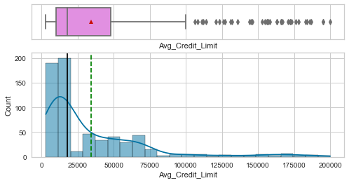

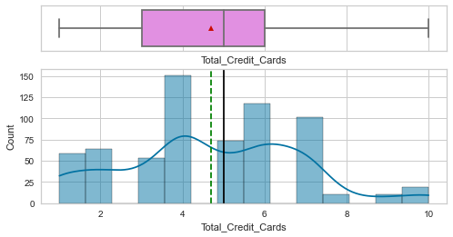

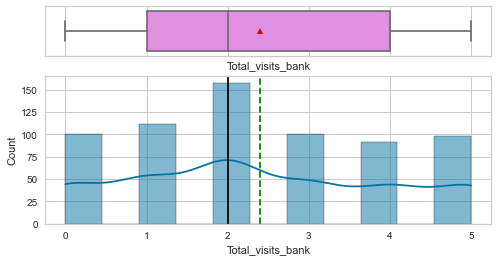

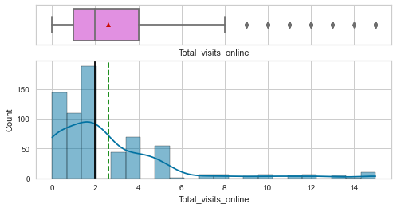

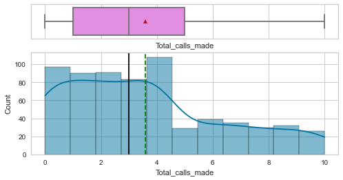

```python
# selecting numerical columns
num_col = cred.select_dtypes(include=np.number).columns.tolist()

for item in num_col:
    histogram_boxplot(cred, item, kde=True, figsize=(8, 4))
```

- There are outliers in column Avg_Credit_Limit, and total visits online
- However it does not look like there are abnormalities in the data, for example, they don't look like as there were mistakes from the data collectors, or they were intentionally modified for a reason
- Total visits online and total call made data looks right skewed, most of the customers are in below average, however few customers have either made many calls or visited

```python
# function to create labeled barplots


def labeled_barplot(data, feature, perc=False, n=None):
    """
    Barplot with percentage at the top

    data: dataframe
    feature: dataframe column
    perc: whether to display percentages instead of count (default is False)
    n: displays the top n category levels (default is None, i.e., display all levels)
    """

    total = len(data[feature])  # length of the column
    count = data[feature].nunique()
    if n is None:
        plt.figure(figsize=(count + 1, 5))
    else:
        plt.figure(figsize=(n + 1, 5))

    plt.xticks(rotation=90, fontsize=15)
    ax = sns.countplot(
        data=data,
        x=feature,
        palette="Paired",
        order=data[feature].value_counts().index[:n].sort_values(),
    )

    for p in ax.patches:
        if perc == True:
            label = "{:.1f}%".format(
                100 * p.get_height() / total
            )  # percentage of each class of the category
        else:
            label = p.get_height()  # count of each level of the category

        x = p.get_x() + p.get_width() / 2  # width of the plot
        y = p.get_height()  # height of the plot

        ax.annotate(
            label,
            (x, y),
            ha="center",
            va="center",
            size=12,
            xytext=(0, 5),
            textcoords="offset points",
        )  # annotate the percentage

    plt.show()  # show the plot
```

[figure not shown]

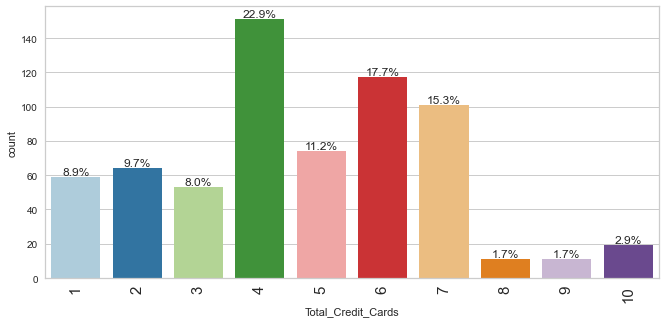

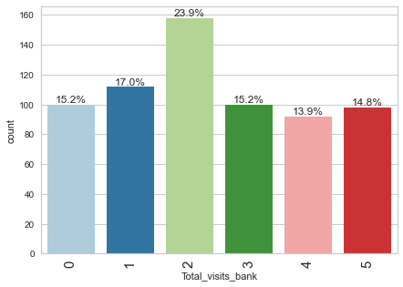

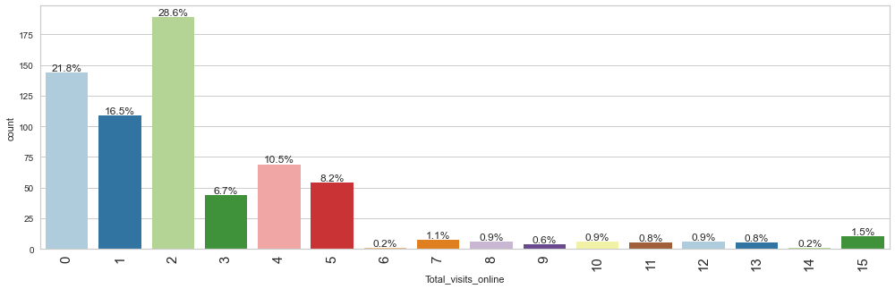

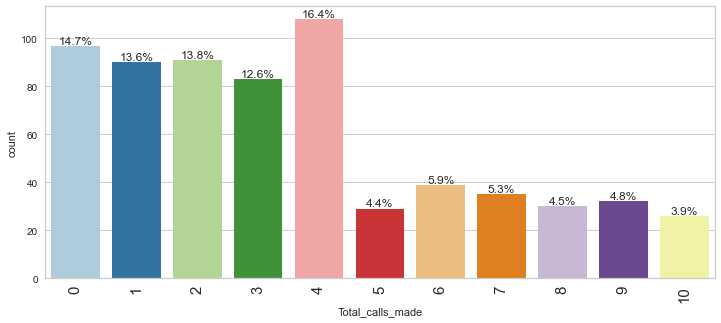

```python
for item in num_col:
    labeled_barplot(cred, item, perc=True)
```

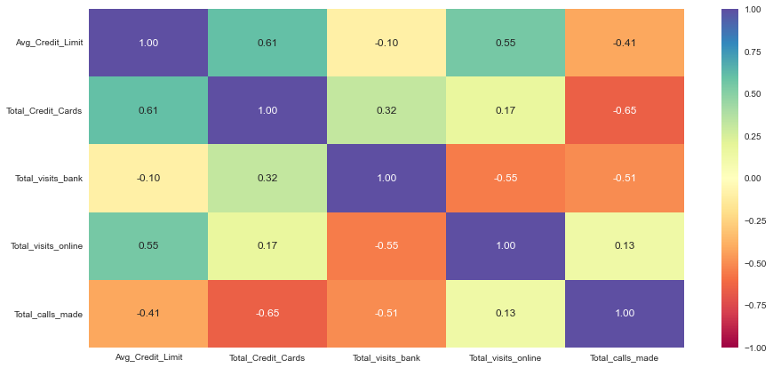

```python
plt.figure(figsize=(15, 7))
sns.heatmap(
    cred[num_col].corr(), annot=True, vmin=-1, vmax=1, fmt=".2f", cmap="Spectral"
)
plt.show()
```

- total credit card is moderately correlated with avg_Credit_card clumn, Who have more credit card, their limit is high. that makes sense.
- Total visits online is negatively corealted with total visits bank. That means who visit online more have less interest to visit physically and vice versa
- Total Credit cards and Total calls made also negatively correlated with one another
- Total calls made also negatively correalted with total visits bank. that also make sense, the customer who do not visit, make call

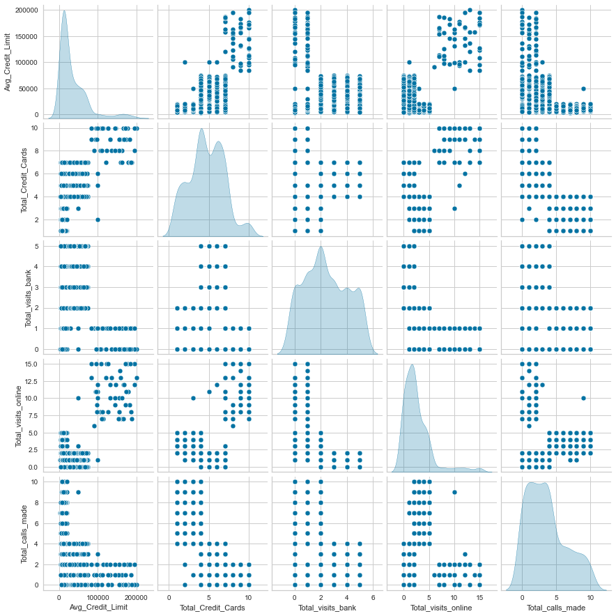

```python
sns.pairplot(data=cred[num_col], diag_kind="kde")
plt.show()
```

# Data Processing

```python
# Scaling the data as there are data of different scales

# Excluding the Customer Key column as this is nominal column only and do not add any value in analysis

scaler = StandardScaler()
subset_scaled_df = pd.DataFrame(
    scaler.fit_transform(cred.drop(["Customer Key"], axis=1)),
    columns=cred.drop(["Customer Key"], axis=1).columns,
)
subset_scaled_df.head()
```

|  | Avg_Credit_Limit | Total_Credit_Cards | Total_visits_bank | Total_visits_online | Total_calls_made |
| --- | --- | --- | --- | --- | --- |
| 0 | 1.740187 | -1.249225 | -0.860451 | -0.547490 | -1.251537 |
| 1 | 0.410293 | -0.787585 | -1.473731 | 2.520519 | 1.891859 |
| 2 | 0.410293 | 1.058973 | -0.860451 | 0.134290 | 0.145528 |
| 3 | -0.121665 | 0.135694 | -0.860451 | -0.547490 | 0.145528 |
| 4 | 1.740187 | 0.597334 | -1.473731 | 3.202298 | -0.203739 |

# Applying K-means Clustering

```
Number of Clusters: 1 	Average Distortion: 2.0069222262503614
Number of Clusters: 2 	Average Distortion: 1.4571553548514269
Number of Clusters: 3 	Average Distortion: 1.1466276549150365
Number of Clusters: 4 	Average Distortion: 1.0463825294774465
Number of Clusters: 5 	Average Distortion: 0.9908683849620168
Number of Clusters: 6 	Average Distortion: 0.9430843103448057
Number of Clusters: 7 	Average Distortion: 0.9095846521660791
Number of Clusters: 8 	Average Distortion: 0.8896731832090814
```

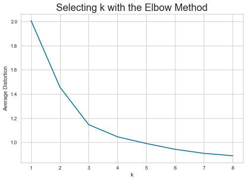

```python
clusters = range(1, 9)
meanDistortions = []

for k in clusters:
    model = KMeans(n_clusters=k)
    model.fit(subset_scaled_df)
    prediction = model.predict(subset_scaled_df)
    distortion = (
        sum(
            np.min(cdist(subset_scaled_df, model.cluster_centers_, "euclidean"), axis=1)
        )
        / subset_scaled_df.shape[0]
    )

    meanDistortions.append(distortion)

    print("Number of Clusters:", k, "\tAverage Distortion:", distortion)

plt.plot(clusters, meanDistortions, "bx-")
plt.xlabel("k")
plt.ylabel("Average Distortion")
plt.title("Selecting k with the Elbow Method", fontsize=20)
```

- From Elbow, we can guess the right number of K will be in between 3 to 5
- Up to K=3, there are sharp fall in distortion and after k=5, the elbow line almost to stagnant
- We can check Silhoette for further understanding

# Sillhouette Score

```
For n_clusters = 2, silhouette score is 0.41842496663215445
For n_clusters = 3, silhouette score is 0.5157182558881063
For n_clusters = 4, silhouette score is 0.3556670619372605
For n_clusters = 5, silhouette score is 0.2717470361089752
For n_clusters = 6, silhouette score is 0.25512159060496997
For n_clusters = 7, silhouette score is 0.2505025396273746
For n_clusters = 8, silhouette score is 0.22721543039961503
For n_clusters = 9, silhouette score is 0.21885207848834295
```

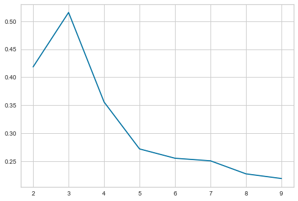

```python
sil_score = []
cluster_list = list(range(2, 10))
for n_clusters in cluster_list:
    clusterer = KMeans(n_clusters=n_clusters)
    preds = clusterer.fit_predict((subset_scaled_df))
    # centers = clusterer.cluster_centers_
    score = silhouette_score(subset_scaled_df, preds)
    sil_score.append(score)
    print("For n_clusters = {}, silhouette score is {}".format(n_clusters, score))

plt.plot(cluster_list, sil_score)
```

- From the Sillhoute score, we see the k=3 has highest sillhoute score followed be k=2
- We can try with 3, 4, and 5 as the number of clusters with Silhouette Visualizer

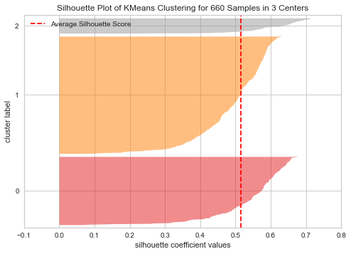

```python
# finding optimal no. of clusters with silhouette coefficients
visualizer = SilhouetteVisualizer(KMeans(3, random_state=1))
visualizer.fit(subset_scaled_df)
visualizer.show()
```

- with k=3, the sillhoutte coefficient values is with all the cluster more than or around 0.6

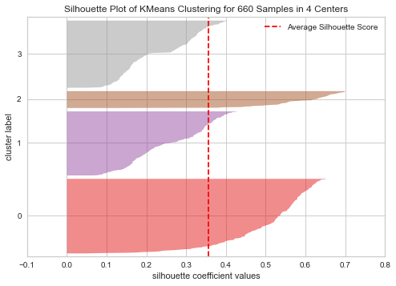

```python
# finding optimal no. of clusters with silhouette coefficients
visualizer = SilhouetteVisualizer(KMeans(4, random_state=1))
visualizer.fit(subset_scaled_df)
visualizer.show()
```

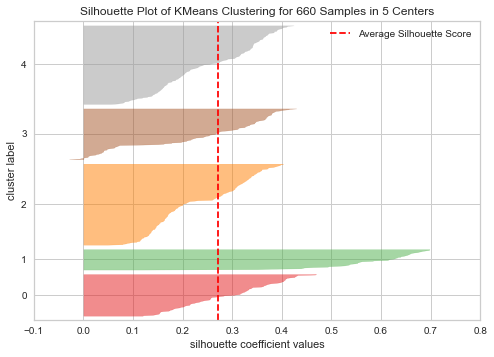

```python
# finding optimal no. of clusters with silhouette coefficients
visualizer = SilhouetteVisualizer(KMeans(5, random_state=1))
visualizer.fit(subset_scaled_df)
visualizer.show()
```

# Cluster Profile

```python
kmeans = KMeans(n_clusters=3, random_state=0)
kmeans.fit(subset_scaled_df)
```

```
KMeans(n_clusters=3, random_state=0)
```

```python
# adding kmeans cluster labels to the original dataframe
cred["K_means_segments"] = kmeans.labels_
```

```python
cluster_profile = cred.groupby("K_means_segments").mean()
```

```python
cluster_profile["count_in_each_segment"] = (
    cred.groupby("K_means_segments")["Avg_Credit_Limit"].count().values
)
```

```python
# let's display cluster profiles
cluster_profile.style.highlight_max(color="lightgreen", axis=0)
```

| K_means_segments | Avg_Credit_Limit | Total_Credit_Cards | Total_visits_bank | Total_visits_online | Total_calls_made | count_in_each_segment |
| --- | --- | --- | --- | --- | --- | --- |
| 0 | 33782.383420 | 5.515544 | 3.489637 | 0.981865 | 2.000000 | 386 |
| 1 | 12174.107143 | 2.410714 | 0.933036 | 3.553571 | 6.870536 | 224 |
| 2 | 141040.000000 | 8.740000 | 0.600000 | 10.900000 | 1.080000 | 50 |

- Customer Segment 0 has the avg. credit limit 33782, total credit cards around 6 and total visits around 3 times. This customer group less willing to visit online. They prefer more visit physically and they are the biggest number of customer.
- Customer segement 1 avg. crdeit limit is 12174, and they hold 2.5 credit catds and they prefer more to call over telephone and they are the second biggest customer segement
- Cusotmer segment 2 is the smallest group, they are more affluent customer with around 9 credit cards and they make a lot of online visit and very relucatanct to go physically and make call over telephone

```python
# let's see the key of the customer in each cluster
for cl in cred["K_means_segments"].unique():
    print("In cluster {}, the following customer are present:".format(cl))
    print(cred[cred["K_means_segments"] == cl]["Customer Key"].unique())
    print()
```

[output not shown]

[output cut: 24 more lines]

[output not shown]

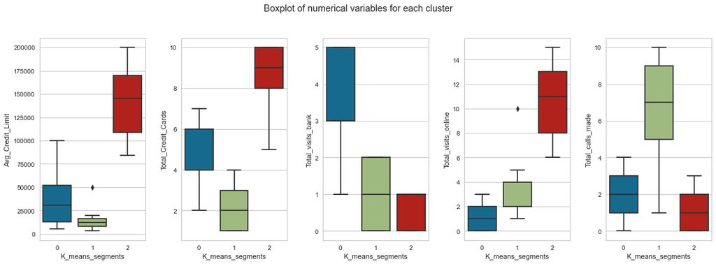

```python
fig, axes = plt.subplots(1, 5, figsize=(16, 6))
fig.suptitle("Boxplot of numerical variables for each cluster")
counter = 0
for ii in range(5):
    sns.boxplot(ax=axes[ii], y=cred[num_col[counter]], x=cred["K_means_segments"])
    counter = counter + 1

fig.tight_layout(pad=2.0)
```

- With avg_cred_limit cluster 0 and 2 are very distnguished, whereas 0 and 1 little bit overlaping wtih one another
- In terms of Total_cred_cards also clusters are distingushed from one another
- However by total visits bank cluster 1 and 2 are overlaping with one another largely, the same also apply for 0 and 2 in Total calls made
- By total visits online, segements are very distinguished from one another
- Credit limit, total credit cards and in generall the type of visits of customer can be important indicators to segment customers and apply marketing and other strategies better. In case of interaction pattern, customer can be divided into two groups, online vs physical visits and call

# Applying Hierarchical Clustering

```python
# list of distance metrics
distance_metrics = ["euclidean", "chebyshev", "mahalanobis", "cityblock"]

# list of linkage methods
linkage_methods = ["single", "complete", "average", "weighted"]

high_cophenet_corr = 0
high_dm_lm = [0, 0]

for dm in distance_metrics:
    for lm in linkage_methods:
        Z = linkage(subset_scaled_df, metric=dm, method=lm)
        c, coph_dists = cophenet(Z, pdist(subset_scaled_df))
        print(
            "Cophenetic correlation for {} distance and {} linkage is {}.".format(
                dm.capitalize(), lm, c
            )
        )
        if high_cophenet_corr < c:
            high_cophenet_corr = c
            high_dm_lm[0] = dm
            high_dm_lm[1] = lm
```

```
Cophenetic correlation for Euclidean distance and single linkage is 0.7391220243806552.
Cophenetic correlation for Euclidean distance and complete linkage is 0.8599730607972423.
Cophenetic correlation for Euclidean distance and average linkage is 0.8977080867389372.
Cophenetic correlation for Euclidean distance and weighted linkage is 0.8861746814895477.
Cophenetic correlation for Chebyshev distance and single linkage is 0.7382354769296767.
Cophenetic correlation for Chebyshev distance and complete linkage is 0.8533474836336782.
Cophenetic correlation for Chebyshev distance and average linkage is 0.8974159511838106.
Cophenetic correlation for Chebyshev distance and weighted linkage is 0.8913624010768603.
Cophenetic correlation for Mahalanobis distance and single linkage is 0.7058064784553606.
Cophenetic correlation for Mahalanobis distance and complete linkage is 0.6663534463875361.
Cophenetic correlation for Mahalanobis distance and average linkage is 0.8326994115042136.
Cophenetic correlation for Mahalanobis distance and weighted linkage is 0.7805990615142518.
Cophenetic correlation for Cityblock distance and single linkage is 0.7252379350252723.
Cophenetic correlation for Cityblock distance and complete linkage is 0.8731477899179829.
Cophenetic correlation for Cityblock distance and average linkage is 0.896329431104133.
Cophenetic correlation for Cityblock distance and weighted linkage is 0.8825520731498188.
```

- As a linkage average is generating better cophenetic correlation value
- Euclidean with average with 0.8977
- Chevyshev with average with 0.8974
- cityblock with average with 0.896
- also weighted and complete linkage with cityblock also generating close enough cophenetic value

```python
# printing the combination of distance metric and linkage method with the highest cophenetic correlation
print(
    "Highest cophenetic correlation is {}, which is obtained with {} distance and {} linkage.".format(
        high_cophenet_corr, high_dm_lm[0].capitalize(), high_dm_lm[1]
    )
)
```

```
Highest cophenetic correlation is 0.8977080867389372, which is obtained with Euclidean distance and average linkage.
```

- As already observed, eulidean distance with average linkage is giving the highest cophenetic value

# Checking different linkage with euclidean

```python
# different linkage methods with only eucledian distance
linkage_methods = ["single", "complete", "average", "centroid", "ward", "weighted"]

high_cophenet_corr = 0
high_dm_lm = [0, 0]

for lm in linkage_methods:
    Z = linkage(subset_scaled_df, metric="euclidean", method=lm)
    c, coph_dists = cophenet(Z, pdist(subset_scaled_df))
    print("Cophenetic correlation for {} linkage is {}.".format(lm, c))
    if high_cophenet_corr < c:
        high_cophenet_corr = c
        high_dm_lm[0] = "euclidean"
        high_dm_lm[1] = lm
```

```
Cophenetic correlation for single linkage is 0.7391220243806552.
Cophenetic correlation for complete linkage is 0.8599730607972423.
Cophenetic correlation for average linkage is 0.8977080867389372.
Cophenetic correlation for centroid linkage is 0.8939385846326323.
Cophenetic correlation for ward linkage is 0.7415156284827493.
Cophenetic correlation for weighted linkage is 0.8861746814895477.
```

```python
# printing the combination of distance metric and linkage method with the highest cophenetic correlation
print(
    "Highest cophenetic correlation is {}, which is obtained with {} linkage.".format(
        high_cophenet_corr, high_dm_lm[1]
    )
)
```

```
Highest cophenetic correlation is 0.8977080867389372, which is obtained with average linkage.
```

# Checking with different linkage metods with chebyshev

```python
# different linkage methods with only chebyshev distance
linkage_methods = ["single", "complete", "average", "weighted"]

high_cophenet_corr = 0
high_dm_lm = [0, 0]

for lm in linkage_methods:
    Z = linkage(subset_scaled_df, metric="chebyshev", method=lm)
    c, coph_dists = cophenet(Z, pdist(subset_scaled_df))
    print("Cophenetic correlation for {} linkage is {}.".format(lm, c))
    if high_cophenet_corr < c:
        high_cophenet_corr = c
        high_dm_lm[0] = "chebyshev"
        high_dm_lm[1] = lm
```

```
Cophenetic correlation for single linkage is 0.7382354769296767.
Cophenetic correlation for complete linkage is 0.8533474836336782.
Cophenetic correlation for average linkage is 0.8974159511838106.
Cophenetic correlation for weighted linkage is 0.8913624010768603.
```

- Chebyshev with average linkae is highest with 0.8974 cophenetic values

# Checking with different linkage metods with Cityblock

```python
# different linkage methods with only chebyshev distance
linkage_methods = ["single", "complete", "average", "weighted"]

high_cophenet_corr = 0
high_dm_lm = [0, 0]

for lm in linkage_methods:
    Z = linkage(subset_scaled_df, metric="cityblock", method=lm)
    c, coph_dists = cophenet(Z, pdist(subset_scaled_df))
    print("Cophenetic correlation for {} linkage is {}.".format(lm, c))
    if high_cophenet_corr < c:
        high_cophenet_corr = c
        high_dm_lm[0] = "cityblock"
        high_dm_lm[1] = lm
```

```
Cophenetic correlation for single linkage is 0.7252379350252723.
Cophenetic correlation for complete linkage is 0.8731477899179829.
Cophenetic correlation for average linkage is 0.896329431104133.
Cophenetic correlation for weighted linkage is 0.8825520731498188.
```

- Cityblock with average linkage is giving 0.896 cophenetic correaltion

# Dendogram for diffent linkage method with Euclidean

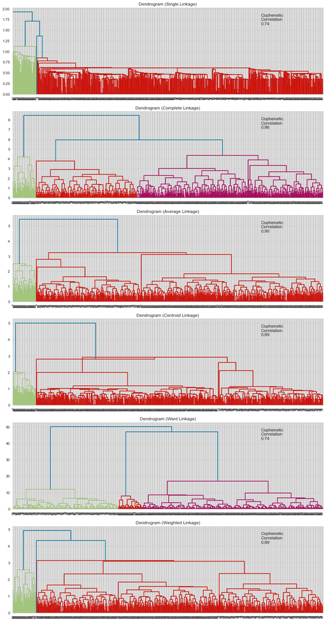

```python
# list of linkage methods
linkage_methods = ["single", "complete", "average", "centroid", "ward", "weighted"]

# lists to save results of cophenetic correlation calculation
compare_cols = ["Linkage", "Cophenetic Coefficient"]

# to create a subplot image
fig, axs = plt.subplots(len(linkage_methods), 1, figsize=(15, 30))

# We will enumerate through the list of linkage methods above
# For each linkage method, we will plot the dendrogram and calculate the cophenetic correlation
for i, method in enumerate(linkage_methods):
    Z = linkage(subset_scaled_df, metric="euclidean", method=method)

    dendrogram(Z, ax=axs[i])
    axs[i].set_title(f"Dendrogram ({method.capitalize()} Linkage)")

    coph_corr, coph_dist = cophenet(Z, pdist(subset_scaled_df))
    axs[i].annotate(
        f"Cophenetic\nCorrelation\n{coph_corr:0.2f}",
        (0.80, 0.80),
        xycoords="axes fraction",
    )
```

- From the dendograms, single, average, complete and ward linkage are suggesting for 3 to 4 clusters
- whereas weighted and centroid linkage are suggesting for 6 or 7 clustes
- So we will go ahead with 3 clusters, eucledean and average